# FARMR!SK automatic report

The main pathways of disease entry are: **Animals from other origin** and **Vehicle visits to the farm**.

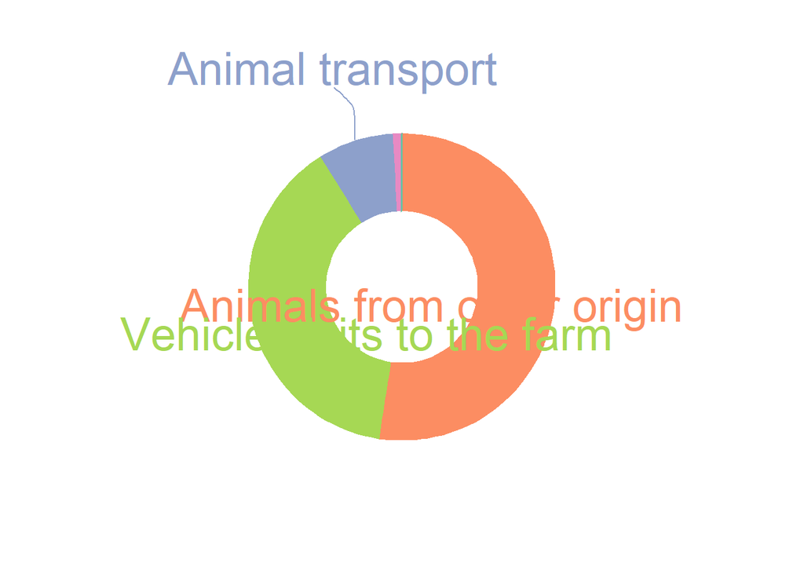

(a) IBR

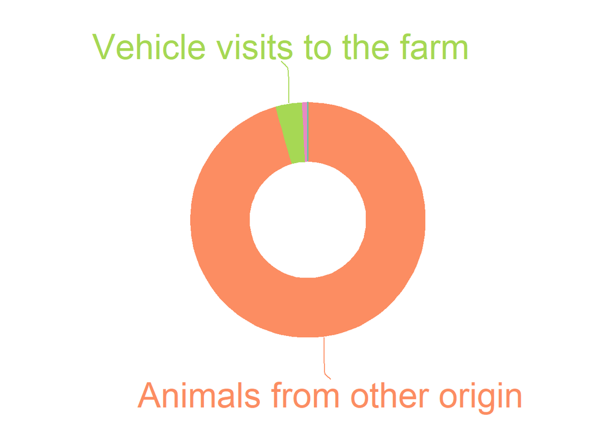

(b) BVD

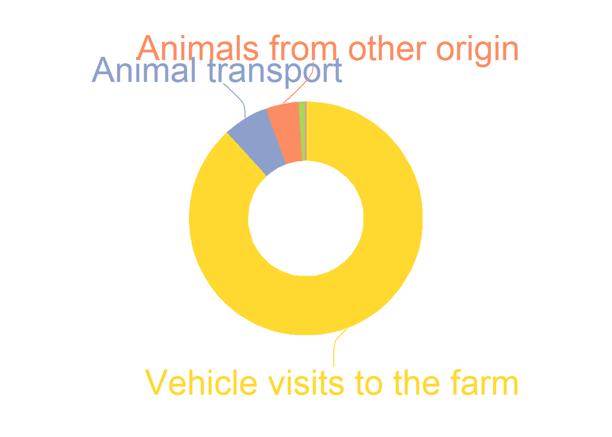

(c) TB

Figure 1.2: Risk of disease entry by pathway

## **Infectious Bovine Rhinotracheitis (IBR)**

### Current risk

Annual risk of IBR entry in the farm: **17.1%** (13.2-22.3%)

By pathway:

- Animals from other origin: **9.4%** (8.56-10.3%)
- Vehicle visits to the farm: **6.94%** (2.73-12.7%)
- Animal transport: **1.43%** (0.705-2.27%)
- People visits to the farm: **0.158%** (0.0534-0.283%)
- Neigbouring farms: **0.00419%** (0.000172-0.0139%)

### Risk reduction of biosecurity measures

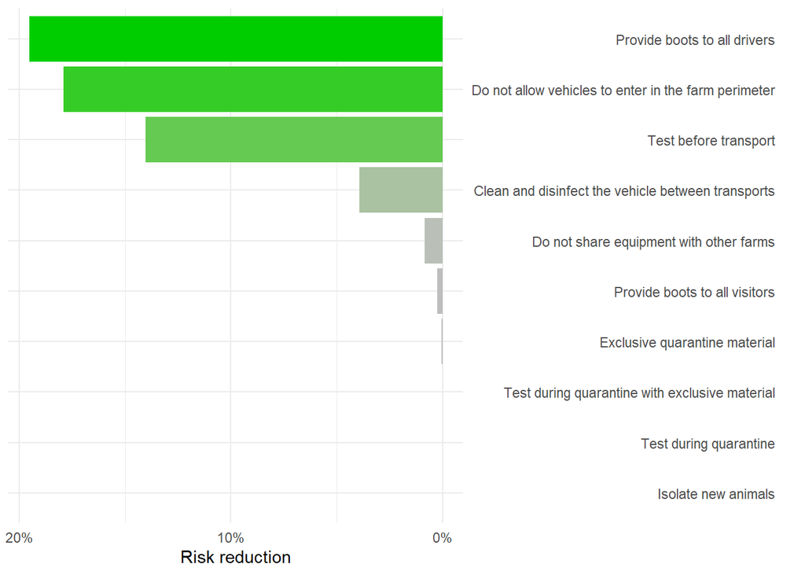

## **Bovine viral diarrhea (BVD)**

### Current risk

Annual risk of BVD entry in the farm: **70.9%** (65.9-75.9%)

By pathway:

- Animals from other origin: **69.9%** (64.7-74.9%)
- Vehicle visits to the farm: **2.68%** (1.12-4.79%)
- People visits to the farm: **0.525%** (0.14-1.19%)
- Animal transport: **0.00925%** (0.0011-0.0683%)
- Neigbouring farms: **1.44e-10%** (5.77e-13-2.27e-09%)

### Risk reduction of biosecurity measures

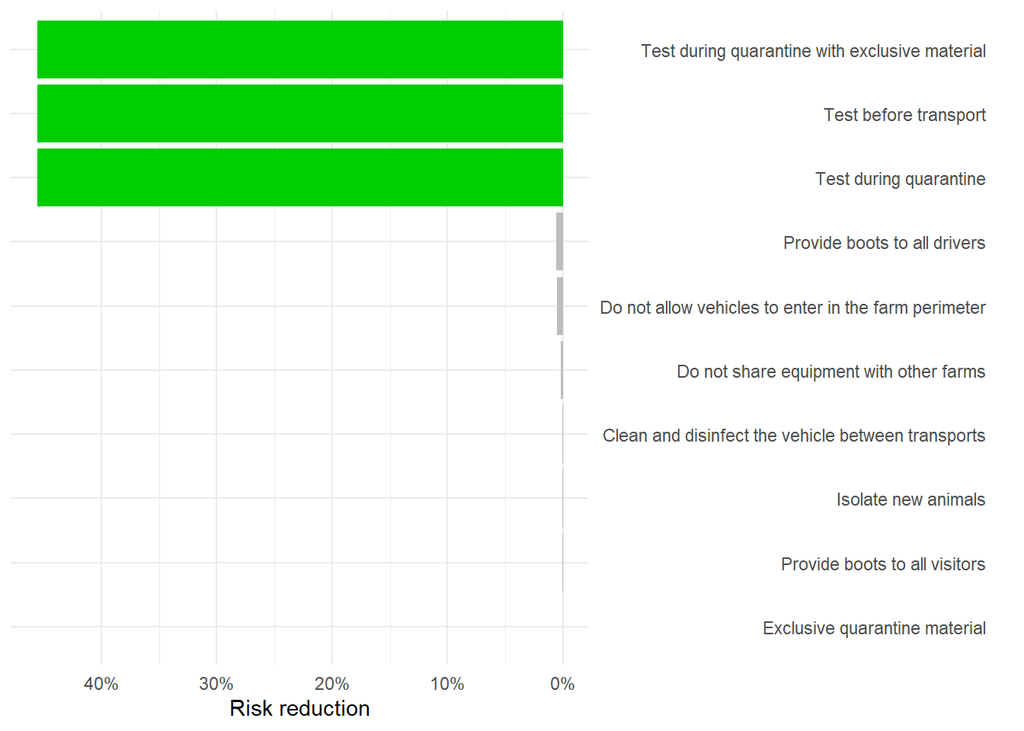

## **Bovine Tuberculosis (TB)**

### Current risk

Annual risk of TB entry in the farm: **0.0166%** (0.00318-0.0691%)

By pathway:

- Vehicle visits to the farm: **0.0145%** (0.00117-0.0678%)
- Animal transport: **0.00102%** (0.000205-0.00296%)
- Animals from other origin: **0.000744%** (0.000471-0.0011%)
- People visits to the farm: **0.000159%** (1.52e-05-0.000704%)
- Neigbouring farms: **6.28e-07%** (2.71e-10-2.06e-05%)
- Wildlife: **9.21e-09%** (1.04e-11-4.06e-07%)

### Risk reduction of biosecurity measures

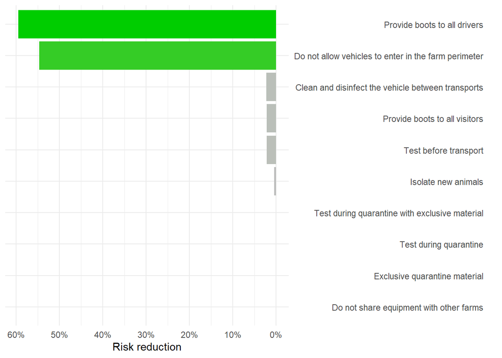

# 🐄 Description of the farm

## Farm information

**Location:** Cataluña, Spain

**Farm type:** Dairy cattle, NA

**Cattle cens:**

- 3 Calves ( <8 m)
- 150 Heifers (8 - 24 m)
- 185 Adult cows (>24 m)
- 0 Bulls

**Other animals in the farm:**

- **Direct contact with cattle:** 2 sheep, 2 dogs, 5 cats
- **No direct contact with cattle:**

**Neighbours**: 1 cattle farms within a 1-2km radious, no direct contact (IBR: 0.00419%, BVD: 1.44e-10%, TB: 6.28e-07%)

## Farm vehicles

| veh_id | Size | Shared | Cleaning |
| --- | --- | --- | --- |
| Vehicle granja veïna (a) | 10m2 | Shared with 1 cattle farms | From time to time |

## Visits

### People entering the barn

| Visit | Type | Frequency | Boots | Equipment | Risk |
| --- | --- | --- | --- | --- | --- |
| Veterinari | External veterinarians | 52 | Always used in other farms, sometimes cleaned and disinfected | Always used in other farms, sometimes cleaned and disinfected | IBR: 0.154%, BVD: 0.512%, TB: 0.000154% |
| Podòleg | Other animal professionals (e.g. hoof trimmer) | 1 | Always used in other farms, sometimes cleaned and disinfected | Always used in other farms, sometimes cleaned and disinfected | IBR: 0.00404%, BVD: 0.0133%, TB: 3.7e-06% |

### Vehicles entering the farm perimeter

| Visit | Type | Frequency | Driver | Risk |
| --- | --- | --- | --- | --- |
| Vaques escorxador | Slaughterhouse vehicle | 12 | Contacts farm animals, boots always used in other farms, never cleaned and disinfected | IBR: 6.17%, BVD: 1.4%, TB: 0.0143% |
| Vedells per engreix | Calf transport vehicle | 24 | Enters areas used by farm animals (no contact with animals), boots always used in other farms, never cleaned and disinfected | IBR: 0.571%, BVD: 1.11%, TB: 0.000163% |
| Camió de la Llet, cooperativa del Cadí | Milk collection vehicle | 365 | - | IBR: 0.0646%, BVD: 0.0122%, TB: 3.63e-06% |
| Unifeed | Feed vehicle | 260 | - | IBR: 0.0598%, BVD: 0.0119%, TB: 5.11e-06% |
| Cadàvers | Rendering vehicle | 12 | - | IBR: 0.00405%, BVD: 0.000789%, TB: 2.75e-07% |
| Fermentat i palla | Feed vehicle | 12 | - | IBR: 0.00259%, BVD: 0.000577%, TB: 1.76e-07% |

# 🚚 Movements

Animal movements in the last 12 months

| mov_id | When | Origin | Animals moved | Shared site | Vehicle used | Risk |
| --- | --- | --- | --- | --- | --- | --- |
| 15_vaques_divers | ➡️ One-off entry: 2023-05-21 | Other farm/s: Lleida | 15 Adult cows (>24 m) | - | Own Vehicle granja veïna | IBR: 5.97%, BVD: 44.7%, TB: 0.000766% |
| 15_vaques_vic | ➡️ Recurrent entry: 1 times/year | Other farm/s: Barcelona | 15 Heifers (8 - 24 m) | - | Own Vehicle granja veïna | IBR: 5.1%, BVD: 45%, TB: 0.000924% |

### Health status and tests in origin

| mov_id | Pathogen | Health status in origin | Test in origin |  |
| --- | --- | --- | --- | --- |
| 15_vaques_divers | BVD | Unknown | - |  |
|  | IBR |  |  |  |
|  | TB |  |  | T3H (Long-term officially free) |
| 15_vaques_vic | BVD | Unknown |  |  |
|  | IBR |  |  |  |
|  | TB |  |  | T3H (Long-term officially free) |

### Quarantine

#### Characteristics

*No quarantine*

# 🐗 Wildlife

**Wildlife:** IBR: -, BVD: -, TB: 9.21e-09%

- Outdoors grazing: Outdoors grazing, no complete perimeter fence (double, electric) (IBR: -, BVD: -, TB: 9.21e-09%)
- Pasture (trashumance): No pastures

### Farm water points

| Waterpoints | Mud |
| --- | --- |
| 100% River | 100% |

### Pasture water points

*No pasture water points*

# Comments

- Vecino separado por un doble vallado (pero muy cerca) (outdoor)
- Unifeed tiene más riesgo que feed vehicle, añadira la encuesta (complete)

# Technical Annex

- Simulation date: 2025-11-18 12:17:25
- Script unification date: 2025-11-17 12:20:43
- Repository: https://github.com/NataliaCiria/biosecurity_model.git
- Last commit: 5b482c75a9928a4d9b1dd0f39f59ed7d93bb09e0
- Last commit date: 2025-11-16 17:22:55
- user_id:
- farm_id: bl8_v1
- Risk timeframe: 360 days
- Calculate all summaries: FALSE
- Automatic what-if scenarios: TRUE
- Analyse model sensitivity: FALSE
- Farm biosecurity survey: bsg_cattle_v4_3_ciria 2015-05-21
- Movements surveys:
  - v4_1_ciria ( 2 ): 15_vaques_vic, 15_vaques_divers